# Traitement du langage naturel avec R

Bruno Tremblay

2019-05-13

# Survol

L’objectif de cet atelier et de vous présenter différentes méthodes pour intégrer des documents dans un contexte d’apprentissage machine. Vous devrez ensuite appliquer ces méthodes pour entraîner un modèle de classification binaire.

À la base, un document doit être transformé en une représentation numérique pour pouvoir être utilisé dans un algorithme d’entraînement.

La technique utilisée pour effectuer cette transformation a un grand impact sur les résultats. C’est ce que nous explorerons aujourd’hui.

# Agenda

1. Base
   - Comment importer des documents (tm, rvest, odbc, jsonlite)
   - Un petit mot sur l’encodage
   - Manipuler des chaînes de caractères (grep it like its hot)
2. Transformations
   - Orthographe (hunspell)
   - Stopwords (tm)
   - Stemming (SnowballC)
   - Collocations
   - Contextes négatifs
   - Matrice de fréquence des termes dans un documents
3. Apprentissage machine

# Atelier

## Base

### Comment importer des documents

#### À partir d’une source de données odbc (odbc)

```r
library(odbc)
docs <- dbGetQuery(dbConnect(odbc(), "DSN"), "SELECT TEXT FROM COMMENTS")
```

#### À partir d’internet (rvest)

```r
library(rvest)
content <- read_html('https://old.reddit.com/r/Quebec/')
submissions <- content %>% html_nodes('a.title') %>% html_text
links <- content %>% html_nodes('a.title') %>% html_attr("href")
rqclatest <- data.frame("submissions" = submissions, "links" = links)
rqclatest
```

```
##                                                                                                      submissions
## 1                                                                              Lundi nostalgies - 13 / 05 / 2019
## 2                                                                                   Nouvel album de Jean Leloup!
## 3                                                                               "Je souhaite que Dieu existe"...
## 4                                                                                                Série Noire ...
## 5                                                                                   Le problème c’est l’anglais!
## 6                                                                                            Question sur la SAQ
## 7                                                          La laïcité: une trajectoire de deux siècles de combat
## 8                                                                                      Juste des bouts de tissu!
## 9                                                                                          Où trouver du rennet?
## 10                                       Le français quasi absent d'une audience sur la réforme du taxi à Québec
## 11                                                                                  Diplôme d'études collégiales
## 12                                       Les Grands Projets Québécois - La Baie-James (Complexe Hydroélectrique)
## 13                                                   "To Be Sold, a Young Negro Lad" - Quebec Herald, mars 1791.
## 14                                                              Le nom de cette épicerie que j'ai vue en Islande
```

[output cut: 39 more lines]

Référence :  
* https://datascienceplus.com/building-a-hacker-news-scraper-with-8-lines-of-r-code-using-rvest-library/

#### À partir de documents pdf ou d’images (tesseract, tm)

```r
library(tesseract)
vignette("intro", "tesseract")
```

Références :  
* https://data.library.virginia.edu/reading-pdf-files-into-r-for-text-mining/ * https://medium.com/@CharlesBordet/how-to-extract-and-clean-data-from-pdf-files-in-r-da11964e252e

#### À partir d’un archive de fichiers json

```r
library(jsonlite)

archive <- "../extract_json_r_20190412.zip"
unzip(archive, overwrite = TRUE, junkpaths = TRUE, exdir = "../json")
files <- dir("../json", full.names = TRUE, recursive = FALSE)
docs <- sapply(files,
                function(file) {
                  content <- readLines(file, encoding = "latin1", warn = FALSE)
                  content <- iconv(content, from = "ISO8859-1", to = "UTF-8")
                  # content <- gsub("\\\\", "\\\\u005C", content)
                  # content <- gsub("\u0008", "\\\\u0008", content)
                  # content <- gsub("\u0009", "\\\\u0009", content)
                  # content <- gsub("\u000A", "\\\\u000A", content)
                  # content <- gsub("\u000C", "\\\\u000C", content)
                  # content <- gsub("\u000D", "\\\\u000D", content)
                  decoded <- try(fromJSON(content))
                  if (class(decoded) == "try-error") {
                    print(file)
                    return()
                  } else {
                    return(decoded$text-content)
                  }
                })
```

#### À partir d’un data déjà créé pour l’atelier d’aujourd’hui

```r
utils::data(collisions, package = "nlpraqc19")
docs <- nlpraqc19::collisions
docs[sample(1:nrow(docs), 5)]
```

```
##                                                                                                                                                                                                                                                                                                          …
## 1:                                                                                                  B2 500 faq20 50/1500\n\nJe suis sur la rue jean-talon et avenue du parc à montreal.\nMa lumière était verte et tp aussi.\nJe sais qu'à ce coin de rue, sa lumière verte est clignotante au départ\nTP…
## 2:                                                                                                                                                                                                                                                                                                       …
## 3: b2 500 b3 250 VANoui 50/1500\nvers 10ham, j'était stationner dans le stationnement  devant de chez grand-mere auto neige a grand-mere. lorsque je quittait je reculait dans l'allé principale dans la rue qui est un sens unique et j'ai frapper le véhicule. le monsieur c'est stationner en arriere …
## 4:                                        fr. 500/250  FAQ 43 A\n**Hors Québec***************\n\nlieu: sortie autoroute 87, New-York sortie Cross Gates Mall Road.\n\nUne auto en a coupé une autre à l'avant et l'auto devant moi a frappé une autre auto et je l'ai frappée par la suite. Personne n'a …
## 5:                                                                                                                                                                                                                                                                                        b2 500 b3 100\n…
##    QUEST_COLLISION_PERTETOT
## 1:                        N
## 2:                        N
## 3:                        N
## 4:                        N
## 5:                        N
```

### Un petit mot sur l’encodage

Si vous voyez apparaître des symboles � inattendus dans vos chaînes de caractères, c’est probablement parce qu’il y a un problème avec l’encodage.

Pour faire une histoire courte, vos programmes utilisent une table d’encodage pour déterminer la correspondance entre la représentation binaire et la représentation symbolique des caractères.

Donc pour s’assurer d’avoir la bonne représentation, il faut effectuer la lecture ou l’écriture des données avec le bon encodage.

```r
# Définir l'encodage au niveau d'une connexion
dbConnect(odbc(), encoding = "latin1")

# Convertir l'encodage d'une chaîne de caractères
iconv(text, from = "ISO8859-1", to = "UTF-8")
```

Référence :  
https://kevinushey.github.io/blog/2018/02/21/string-encoding-and-r/

### Manipuler des chaînes de caractères (grep it like its hot)

Il y a quelques outils de base qui sont indispensables à la manipulation de chaînes de caractères.

#### grep, gsub et expressions régulières

```r
grep("chat", collisions$QUEST_CICH_COMNT)[1:3]
```

```
## [1] 105 106 122
```

Ça nous donne l’indice mais si on veut la valeur.

```r
grep("chat", collisions$QUEST_CICH_COMNT, value = TRUE)[1:3]
```

```
## [1] "b2 250 b3 50\nLieu Centre d'achat thandler galeries\nCe matin j'ai remarqué une bosse sur ma portiere arriere  passager"
## [2] "Le fils de n/a (Gabriel) conduisait l'auto de n/a.. il circulait sur la rue Corosol à Sept Iles.. il a voulu éviter un chat et a glissé car chaussée glacée et a frappé une bordure de trottoir"
## [3] "b2/500////////////////////b3/100\nassuré est au centre d'achat lafleche environ 15h et il y a un bris sur l'auto de n/a ,surement bris avec une boulle de remorue"
```

C’est pas tout à fait ça, on veut le mot chat donc il faut mieux définir notre expression de recherche. Ajoutons l’option d’ignorer minuscule masjucule.

```r
grep("\\bchat\\b", collisions$QUEST_CICH_COMNT, value = TRUE, ignore.case = TRUE)[1:3]
```

```
## [1] "Le fils de n/a (Gabriel) conduisait l'auto de n/a.. il circulait sur la rue Corosol à Sept Iles.. il a voulu éviter un chat et a glissé car chaussée glacée et a frappé une bordure de trottoir"
## [2] "250/100\ncentre da chat sur hymus a kirkland\nj etais stationné et le tiers m a heurté\nj ai ces infos"
## [3] "500/250\nConjoint au volant // Luis Brito\nRue Dumas à Beloeil.\nJ'ai voulu éviter un chat et j'ai percuté la chaine de trotoir."
```

Les expressions régulières sont très puissantes. Elles permettent de trouver rapidement de l’information. Maîtriser les et dominer les mondes… ou presque.

```r
?regex
```

Vous pouvez expérimenter avec différentes expressions pour identifier des cas. C’est comme un où est Charlie.

Trouver quelqu’un qui est rentré dans un arbre.

```r
txt <- collisions$QUEST_CICH_COMNT
grep("\\brentr", txt[grep("\\barbre\\b",txt)], value = TRUE, ignore.case = TRUE)[1]
```

```
## [1] "franc 250\nj'ai voulu rentrer de reculons dans l,entrée du chalet et heurté un arbre. j'ai pris le vt de la propriétaire du chalet et exceptionnelllmnt j'ai conduis sa voiture parce qu'elle était neuve voulais l'essayer"
```

Bonjour la police

```r
grep("voiture de police|char de police", txt, value = TRUE, ignore.case = TRUE)[1:3]
```

```
## [1] "500/500\nLieux : sur 73 Nord à Lévis\nMon mari conduisait :\nUn camion qui a tamponné à 3 reprises mon mari. On a fait une déclaration à la Sureté du Québec. Il y avait une voiture de police qui était présente et pour éviter la voiture de police, mon mari a changé de voie mais ça n'a pas plu…
## [2] "500/250\n\nLieu : Laval Secteur de St-Francois chemin de campagne\n\n1 voie dans chaque sens\nUn ambulance et une voiture de police ce trouvait dans le chemin à gauche et le monde ce sont mis à arrêter pour voir ce qui se passait un ma mère était le dernier vh est entré en collision avec le …
## [3] "b2 500 b3 250 mpprovost\n\nLieu: boul du Séminaire,coin du poste de police, Saint-Jean-sur-Richelieu\n\nJ'avais une lumière verte, mais j'ai du m'immobilisé car une voiture de police devait passer mais tiers en arriere a glissé sur la glace et m'a percuté."
```

Est-ce que je peux avoir votre code postal?

```r
grep("[a-z][0-9][a-z][ -]?[[:digit:]][[:alpha:]][[:digit:]]", txt, value = TRUE, ignore.case = TRUE)[1:3]
```

```
## [1] "b2 250 b3 50\nLieu: stationnement du travail conjointe à trois-rivières 3125 boul des récollets G9A6M1\nMa voiture était stationnée dans le stationnement de mon travail et un collègue a accroché ma voiture avec sa boule."
## [2] "250/100 DÉLIT DE FUITE\nlieu: possiblement au: 3103 Boulevard Royal, Shawinigan, QC G9N 7C3\nJ'ai constaté des dommages sur mon vh, sur le côté passager. \n"
## [3] "500-250*//*////929-8945 cell**--*-*-*\n*****garage jeanot 2132 lapierre g3e1l8 4188433686*****\n131, rue beauchaine\n\nMon v/a était stationné dans la rue et quand j'ai repris mon v/a il était brissé\n\n"
```

La fonction gsub sert à effectuer des remplacements. Elle pourrait servir à retirer les informations sensibles des champs textes comme les numéros de téléphones.

```r
phonepattern <- "\\b\\(?([0-9]{3})\\)?[-. ]?([0-9]{3})[-. ]?([0-9]{4})\\b"
findtel <- grep(phonepattern, txt, value = TRUE, ignore.case = TRUE)[1]
data.frame("origine" = findtel, "remplacement" = gsub(phonepattern, "", findtel))
```

```
##                                                                                                                                                                                                          origine
## 1 ****TELEPAGE**** accident de véhicule, autre numéro pour rejoindre l'assuré 514-518-6738\nMa petite fille qui prends mon vh occasionnellement était sur le bl labelle et un vh sortant de tim horton l'a coupé
##                                                                                                                                                                                         remplacement
## 1 ****TELEPAGE**** accident de véhicule, autre numéro pour rejoindre l'assuré \nMa petite fille qui prends mon vh occasionnellement était sur le bl labelle et un vh sortant de tim horton l'a coupé
```

Les fonctions gregexpr et regmatches permettent d’extraire les valeurs directement des chaînes de caractères.

```r
parsed <- gregexpr(phonepattern, txt)
matches <- regmatches(txt, parsed)
unlist(unlist(matches))[1:3]
```

```
## [1] "514-518-6738" "5146680352"   "819 962 2224"
```

#### Autres fonctions utiles

Les fonctions substr, strsplit, paste, paste0, tolower, toupper sont également très pratiques.

```r
phrase <- sample(txt, 1)
substr(phrase, max(1, nchar(phrase) - 10), nchar(phrase))
```

```
## [1] " est bossée"
```

```r
strsplit(phrase, "[^-'[:alnum:]]+")
```

```
## [[1]]
##  [1] "fr"         "500"        "250"        "43a"        "e"
##  [6] "En"         "face"       "de"         "la"         "maison"
## [11] "le"         "vt"         "s'est"      "fait"       "vandaliser"
## [16] "durant"     "la"         "nuit"       "Le"         "mirroir"
## [21] "a"          "été"        "arraché"    "il"         "y"
## [26] "a"          "une"        "grande"     "graffigne"  "sur"
## [31] "la"         "porte"      "conducteur" "et"         "l'aile"
## [36] "est"        "bossée"
```

```r
paste("sors avec", unlist(strsplit(phrase, "[^[:alnum:]]+")))
```

```
##  [1] "sors avec fr"         "sors avec 500"        "sors avec 250"
##  [4] "sors avec 43a"        "sors avec e"          "sors avec En"
##  [7] "sors avec face"       "sors avec de"         "sors avec la"
## [10] "sors avec maison"     "sors avec le"         "sors avec vt"
## [13] "sors avec s"          "sors avec est"        "sors avec fait"
## [16] "sors avec vandaliser" "sors avec durant"     "sors avec la"
## [19] "sors avec nuit"       "sors avec Le"         "sors avec mirroir"
## [22] "sors avec a"          "sors avec été"        "sors avec arraché"
## [25] "sors avec il"         "sors avec y"          "sors avec a"
## [28] "sors avec une"        "sors avec grande"     "sors avec graffigne"
## [31] "sors avec sur"        "sors avec la"         "sors avec porte"
## [34] "sors avec conducteur" "sors avec et"         "sors avec l"
## [37] "sors avec aile"       "sors avec est"        "sors avec bossée"
```

```r
paste0(21:31, collapse = ",")
```

```
## [1] "21,22,23,24,25,26,27,28,29,30,31"
```

```r
toupper(phrase)
```

```
## [1] "FR 500/250\n43A&E\nEN FACE DE LA MAISON, LE VT S'EST FAIT VANDALISER DURANT LA NUIT. LE MIRROIR A ÉTÉ ARRACHÉ, IL Y A UNE GRANDE GRAFFIGNE SUR LA PORTE CONDUCTEUR ET L'AILE EST BOSSÉE"
```

## Transformations

### Orthographes

Le package hunspell permet de valider l’orthographe de textes.

Charger hunspell

```r
library(hunspell)
```

```r
custom_words <- c("b2","b3","tp","vh","boul","v\U00e9h","faq","vt","faq20",
                 "veh","mtl","43a","qc","rdp","dir","43ae","cond","domms",
                 "20a","iga","aut","ins","ste","st","blv","domm","pcq","bags",
                 "43e","rp","coord","faq43a","berpa","13c","faq27","str")
dict_fr <- dictionary(paste0(tempd, "\\", grep("\\.dic", dicts, value = TRUE)), add_words = custom_words)
dict_en <- dictionary("en_CA", add_words = custom_words)
```

Maintenant regardons des phrases dans nos données.

```r
phrases <- sample(txt, 5)
words <- hunspell_parse(phrases, dict = dict_fr)
correct <- lapply(words, hunspell_check, dict_fr)
sapply(correct, all)
```

```
## [1] FALSE FALSE FALSE FALSE FALSE
```

Trouvez les mots mal orthographiés ou non reconnus.

```r
bad <- lapply(1:length(words),function(x) {words[[x]][!correct[[x]]]})
bad
```

```
## [[1]]
## [1] "arriere"
##
## [[2]]
## [1] "Autonum"    "Inc."       "passagé"    "parrallère"
##
## [[3]]
## [1] "lumiere"
##
## [[4]]
## [1] "picardie" "quebec"   "neigait"
##
## [[5]]
## [1] "lachanaie" "jai"       "eviter"    "apellé"    "jai"       "apellé"
## [7] "materiel"
```

On peut aussi passer par hunspell directement.

```r
hunspell(phrases, dict = dict_fr)
```

```
## [[1]]
## [1] "arriere"
##
## [[2]]
## [1] "Autonum"    "Inc."       "passagé"    "parrallère"
##
## [[3]]
## [1] "lumiere"
##
## [[4]]
## [1] "picardie" "quebec"   "neigait"
##
## [[5]]
## [1] "lachanaie" "jai"       "eviter"    "apellé"    "jai"       "apellé"
## [7] "materiel"
```

Qu’est-ce que le dictionaire propose?

```r
lapply(bad, function(x) {
  suggest <- hunspell_suggest(x, dict = dict_fr)
  names(suggest) <- x
  suggest
  })
```

```
## [[1]]
## [[1]]$arriere
## [1] "arriéré" "arriérè" "arrière"
##
##
## [[2]]
## [[2]]$Autonum
## [1] "Autonome"
##
## [[2]]$Inc.
## [1] "Inn"  "In"   "Inca" "Zinc" "Ins"  "In c"
##
## [[2]]$passagé
## [1] "pacagé"  "passage" "paysagé"
##
## [[2]]$parrallère
## [1] "parallèle"
##
##
## [[3]]
## [[3]]$lumiere
## [1] "lumière"
##
##
## [[4]]
## [[4]]$picardie
## [1] "Picardie" "picarde"
##
## [[4]]$quebec
## [1] "que bec" "que-bec" "becquet"
##
## [[4]]$neigait
## [1] "neigeait"
##
##
## [[5]]
## [[5]]$lachanaie
## [1] "achalasie"
##
## [[5]]$jai
##  [1] "j’ai" "Jay"  "ai"   "jais" "jas"  "jan"  "jar"  "rai"  "lai"  "jam"
## [11] "mai"  "gai"  "bai"  "wai"
##
## [[5]]$eviter
## [1] "éviter"
##
## [[5]]$apellé
## [1] "pellé"   "a pellé" "appelé"  "capelé"
##
## [[5]]$jai
##  [1] "j’ai" "Jay"  "ai"   "jais" "jas"  "jan"  "jar"  "rai"  "lai"  "jam"
## [11] "mai"  "gai"  "bai"  "wai"
##
## [[5]]$apellé
## [1] "pellé"   "a pellé" "appelé"  "capelé"
##
## [[5]]$materiel
## [1] "matériel"  "maternel"  "materiez"  "mate riel" "mate-riel"
```

Tentative d’autocorrection. Si plus de 50% des mots sont mal orthographiés, on va assumer que c’est de l’anglais. Pas efficace mais honnête.

```r
autocorrect <- function(txt, dict, alt_dict) {
  parsed <- hunspell_parse(txt, dict = dict)
  checked <- lapply(parsed, hunspell_check, dict = dict)
  suggested <- lapply(1:length(parsed), function(i) {
    if (!all(checked[[i]])) {
      if (sum(!checked[[i]])/length(checked[[i]]) > 0.5) {
        checked[[i]] <- hunspell_check(parsed[[i]], alt_dict)
        dict_suggest <- alt_dict
      } else {
        dict_suggest <- dict
      }
      suggested <- unlist(lapply(hunspell_suggest(parsed[[i]][!checked[[i]]], dict = dict_suggest), `[`, 1))
      parsed[[i]][!checked[[i]]] <- ifelse(is.na(suggested), parsed[[i]][!checked[[i]]], suggested)
    }
    parsed[[i]]
  })
  return(unlist(lapply(suggested, paste, collapse = " ")))
}
```

On essaie.

```r
autocorrect(phrases, dict_fr, dict_en)
autocorrect("hi, grandma? can u come pyck me up from my rap batttle? it's over. no, i lost. he saw u droop me off & did a prety devastating rhyme about it", dict_fr, dict_en)
```

[output not shown]

La réalité de la vie c’est que les données ne sont pas toujours parfaite et que la correction de mots sans contexte c’est pas facile. Il n’y a pas encore d’intégration de `grammalecte` avec R, mais ça existe en python via `reticulate`. À explorer.

### Racine des mots *Optionel*

Avec SnowballC. Des fois c’est utile pour réduire la taille d’un vocabulaire.

```r
library(SnowballC)
lapply(strsplit(phrases, "[^-'[:alnum:]]+"), wordStem, language = "french")
```

```
## [[1]]
##  [1] "500"      "250"      "J'ai"     "recul"    "sur"      "la"
##  [7] "voitur"   "de"       "mon"      "ami"      "me"       "dommag"
## [13] "sont"     "sur"      "le"       "parechoc" "et"       "le"
## [19] "cot"      "arrier"   "gauch"
##
## [[2]]
##  [1] "Montréal"  "Autonum"   "Presto"    "Locat"     "inc"
##  [6] "B2"        "500"       "B3"        "500"       "En"
## [11] "sort"      "du"        "pont"      "Jacqu"     "Carti"
## [16] "direct"    "nord"      "la"        "ru"        "qui"
## [21] "continu"   "apres"     "le"        "pont"      "c'est"
## [26] "deux"      "voi"       "dan"       "un"        "sen"
## [31] "uniqu"     "J'ai"      "gliss"     "et"        "heurt"
## [36] "avec"      "mon"       "dev"       "côt"       "passag"
```

[output cut: 28 more lines]

### Présentation du package text2vec

#### La vectorisation

On reprend les guides de http://text2vec.org mais avec nos données. Tout le crédit va à Dmitriy Selivanov, envoyez lui du love.

Le setup.

```r
library(text2vec)
set.seed(3.1416)
model_data <- collisions[, .(QUEST_CICH_COMNT)]
model_data[, target := ifelse(collisions$QUEST_COLLISION_PERTETOT == "O", 1, 0)]
model_data[, id := .I]
all_ids <- model_data$id
train_ids <- sample(all_ids, 80000)
test_ids <- setdiff(all_ids, train_ids)
train <- model_data[train_ids]
test <- model_data[test_ids]
```

Représentation des documents dans l’espace vectoriel avec le vocabulaire. Pour l’instant on va utiliser un preprocessor de base.

```r
prep_fun <- tolower
tok_fun <- word_tokenizer

it_train <- itoken(train$QUEST_CICH_COMNT,
             preprocessor = prep_fun,
             tokenizer = tok_fun,
             ids = train$id,
             progressbar = FALSE)
vocab <- create_vocabulary(it_train)
```

Le vocabulaire c’est juste un data.frame avec les mots et des compteurs.

```r
head(vocab)
```

```
## Number of docs: 80000
## 0 stopwords:  ...
## ngram_min = 1; ngram_max = 1
## Vocabulary:
##         term term_count doc_count
## 1:     chemn          1         1
## 2:  écrivait          1         1
## 3: descageux          1         1
## 4:  44373571          1         1
## 5:     14h55          1         1
## 6:   trayler          1         1
```

La matrice de fréquence des termes dans des documents.

```r
vectorizer <- vocab_vectorizer(vocab)
dtm_train <- create_dtm(it_train, vectorizer)
dim(dtm_train)
```

```
## [1] 80000 59113
```

```r
identical(rownames(dtm_train), as.character(train$id))
```

```
## [1] TRUE
```

Le premier modèle. *Optionel*

```r
library(glmnet)
glmnet_classifier <- cv.glmnet(x = dtm_train, y = train[["target"]],
                              family = 'binomial',
                              # L1 penalty
                              alpha = 1,
                              # interested in the area under ROC curve
                              type.measure = "auc",
                              # n-fold cross-validation
                              nfolds = 4,
                              # high value is less accurate, but has faster training
                              thresh = 1e-3,
                              # again lower number of iterations for faster training
                              maxit = 1e3)
```

Il était un fois un graphique.

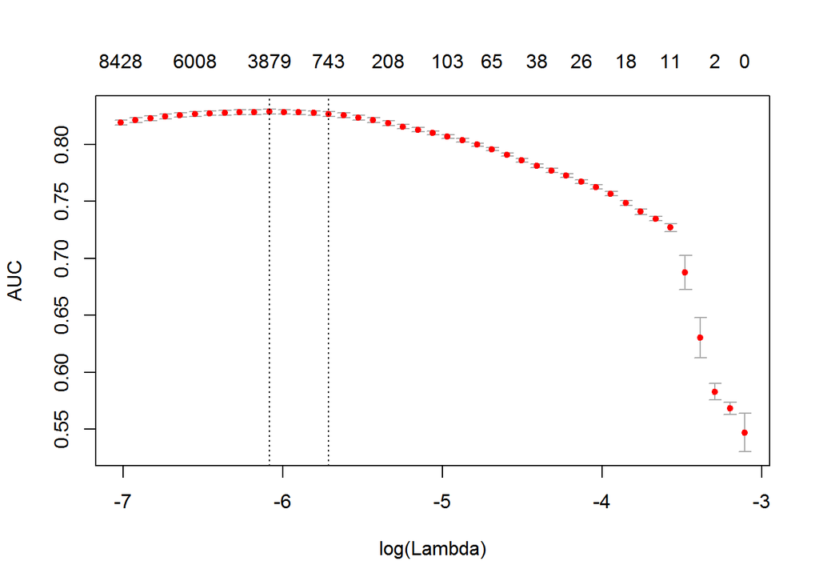

```r
plot(glmnet_classifier)
```

Mais c’est un AUC!

```r
print(paste("max AUC =", round(max(glmnet_classifier$cvm), 4)))
```

```
## [1] "max AUC = 0.8287"
```

On peut reprendre le même vectorizer pour regarder la performance sur la validation. Je veux pas voler de punch mais c’est comme GoT 8. Va falloir travailler plus fort!

```r
it_test <- itoken(test$QUEST_CICH_COMNT,
             preprocessor = prep_fun,
             tokenizer = tok_fun,
             ids = test$id,
             progressbar = FALSE)

dtm_test = create_dtm(it_test, vectorizer)

preds <- predict(glmnet_classifier, dtm_test, type = 'response')[,1]
glmnet:::auc(test$target, preds)
```

```
## [1] 0.8284865
```

Réduire la taille du vocabulaire.

Quand on enlève les stopwords, on perds les contextes négatifs.

```r
swe <- tm::stopwords("en")
swf <- tm::stopwords("fr")
stop_words <- c(swe, swf)
vocab <- create_vocabulary(it_train, stopwords = stop_words)
```

```r
pruned_vocab <- prune_vocabulary(vocab,
                                 term_count_min = 50,
                                 doc_proportion_max = 0.95)
vectorizer <- vocab_vectorizer(pruned_vocab)
dtm_train  <- create_dtm(it_train, vectorizer)
```

```r
dim(dtm_train)
```

```
## [1] 80000  2761
```

```r
dtm_test <- create_dtm(it_test, vectorizer)
dim(dtm_test)
```

```
## [1] 20000  2761
```

Les n-grams ou comment fusionner des mots.

```r
vocab <- create_vocabulary(it_train, ngram = c(1L, 2L), stopwords = stop_words)
```

```r
vocab <- prune_vocabulary(vocab,
                          term_count_min = 50,
                          doc_proportion_max = 0.95)

bigram_vectorizer <- vocab_vectorizer(vocab)

dtm_train <- create_dtm(it_train, bigram_vectorizer)

glmnet_classifier <- cv.glmnet(x = dtm_train, y = train[['target']],
                 family = 'binomial',
                 alpha = 1,
                 type.measure = "auc",
                 nfolds = 4,
                 thresh = 1e-3,
                 maxit = 1e3)
```

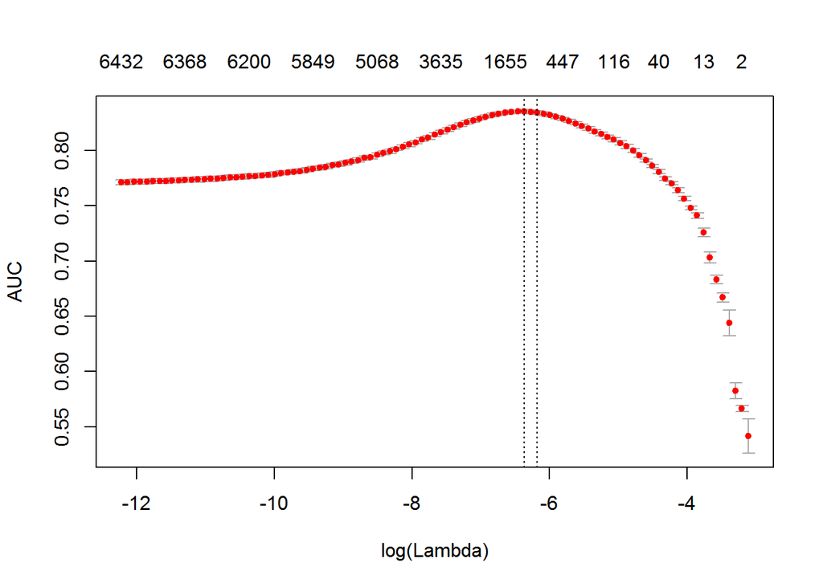

```r
plot(glmnet_classifier)
```

```r
print(paste("max AUC =", round(max(glmnet_classifier$cvm), 4)))
```

```
## [1] "max AUC = 0.8352"
```

```r
dtm_test <- create_dtm(it_test, bigram_vectorizer)
preds <- predict(glmnet_classifier, dtm_test, type = 'response')[,1]
glmnet:::auc(test$target, preds)
```

```
## [1] 0.8358845
```

Hash hash baby

```r
h_vectorizer <- hash_vectorizer(hash_size = 2 ^ 14, ngram = c(1L, 2L))
dtm_train <- create_dtm(it_train, h_vectorizer)
```

```r
glmnet_classifier <- cv.glmnet(x = dtm_train, y = train[['target']],
                             family = 'binomial',
                             alpha = 1,
                             type.measure = "auc",
                             nfolds = 5,
                             thresh = 1e-3,
                             maxit = 1e3)
```

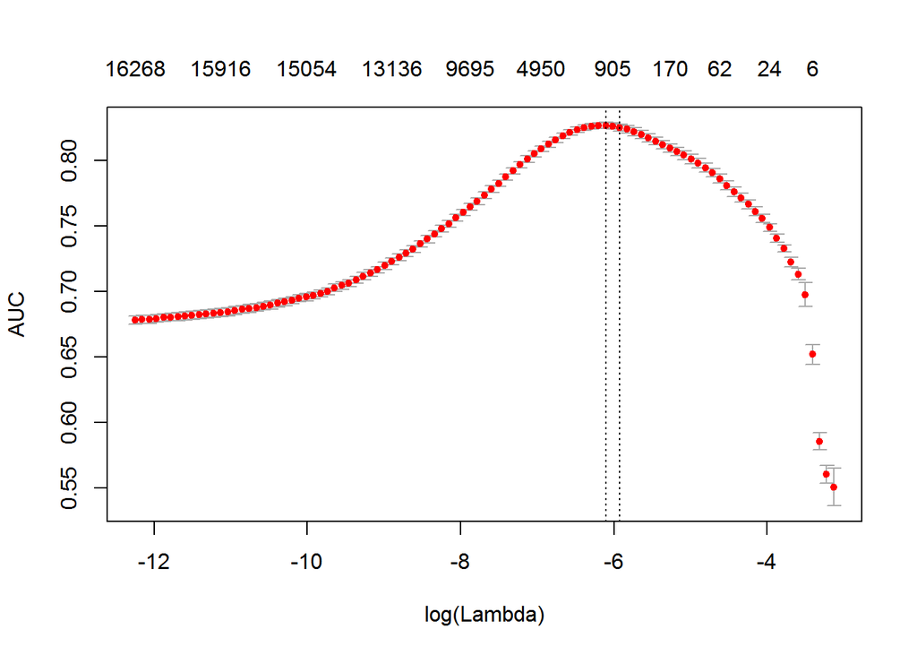

```r
plot(glmnet_classifier)
```

```r
print(paste("max AUC =", round(max(glmnet_classifier$cvm), 4)))
```

```
## [1] "max AUC = 0.8266"
```

```r
dtm_test <- create_dtm(it_test, h_vectorizer)
preds <- predict(glmnet_classifier, dtm_test , type = 'response')[, 1]
glmnet:::auc(test$target, preds)
```

```
## [1] 0.8254771
```

Transformation de base

Normalisation

```r
dtm_train_l1_norm <- normalize(dtm_train, "l1")
```

TF-IDF

```r
vocab <- create_vocabulary(it_train)
vectorizer <- vocab_vectorizer(vocab)
dtm_train <- create_dtm(it_train, vectorizer)

# define tfidf model
tfidf <- TfIdf$new()
# fit model to train data and transform train data with fitted model
dtm_train_tfidf <- fit_transform(dtm_train, tfidf)
# tfidf modified by fit_transform() call!
# apply pre-trained tf-idf transformation to test data
dtm_test_tfidf <- tfidf$transform(create_dtm(it_test, vectorizer))
```

```r
glmnet_classifier <- cv.glmnet(x = dtm_train_tfidf, y = train[['target']],
                              family = 'binomial',
                              alpha = 1,
                              type.measure = "auc",
                              nfolds = 4,
                              thresh = 1e-3,
                              maxit = 1e3)
```

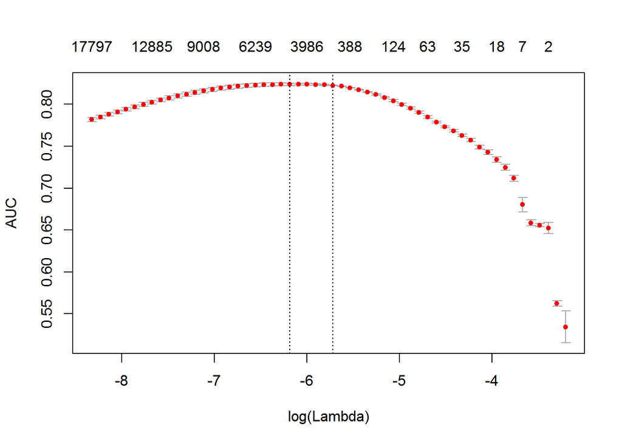

```r
plot(glmnet_classifier)
```

```r
print(paste("max AUC =", round(max(glmnet_classifier$cvm), 4)))
```

```
## [1] "max AUC = 0.8239"
```

```r
preds <- predict(glmnet_classifier, dtm_test_tfidf, type = 'response')[,1]
glmnet:::auc(test$target, preds)
```

```
## [1] 0.8266101
```

#### GloVe embeddings

```r
itk <- itoken(collisions$QUEST_CICH_COMNT,
              preprocessor = tolower,
              tokenizer = tok_fun,
              ids = collisions[, id := .I]$id,
              progressbar = FALSE)
vocab <- create_vocabulary(itk)
```

```r
vocab <- prune_vocabulary(vocab, term_count_min = 10)
```

```r
vectorizer <- vocab_vectorizer(vocab)
tcm <- create_tcm(itk, vectorizer, skip_grams_window = 7L)
```

Fits like a GloVe

```r
glove <- GlobalVectors$new(word_vectors_size = 50, vocabulary = vocab, x_max = 50)
wv_main <- glove$fit_transform(tcm, n_iter = 25, convergence_tol = 0.001)
```

```
## INFO [2019-05-13 07:37:02] 2019-05-13 07:37:02 - epoch 1, expected cost 0.0618
## INFO [2019-05-13 07:37:03] 2019-05-13 07:37:03 - epoch 2, expected cost 0.0338
## INFO [2019-05-13 07:37:04] 2019-05-13 07:37:04 - epoch 3, expected cost 0.0276
## INFO [2019-05-13 07:37:05] 2019-05-13 07:37:05 - epoch 4, expected cost 0.0242
## INFO [2019-05-13 07:37:06] 2019-05-13 07:37:06 - epoch 5, expected cost 0.0219
## INFO [2019-05-13 07:37:08] 2019-05-13 07:37:08 - epoch 6, expected cost 0.0203
## INFO [2019-05-13 07:37:09] 2019-05-13 07:37:09 - epoch 7, expected cost 0.0192
## INFO [2019-05-13 07:37:10] 2019-05-13 07:37:10 - epoch 8, expected cost 0.0182
## INFO [2019-05-13 07:37:11] 2019-05-13 07:37:11 - epoch 9, expected cost 0.0175
## INFO [2019-05-13 07:37:12] 2019-05-13 07:37:12 - epoch 10, expected cost 0.0169
## INFO [2019-05-13 07:37:13] 2019-05-13 07:37:13 - epoch 11, expected cost 0.0164
## INFO [2019-05-13 07:37:15] 2019-05-13 07:37:15 - epoch 12, expected cost 0.0160
## INFO [2019-05-13 07:37:16] 2019-05-13 07:37:16 - epoch 13, expected cost 0.0156
## INFO [2019-05-13 07:37:17] 2019-05-13 07:37:17 - epoch 14, expected cost 0.0153
## INFO [2019-05-13 07:37:18] 2019-05-13 07:37:18 - epoch 15, expected cost 0.0150
## INFO [2019-05-13 07:37:19] 2019-05-13 07:37:19 - epoch 16, expected cost 0.0148
## INFO [2019-05-13 07:37:20] 2019-05-13 07:37:20 - epoch 17, expected cost 0.0146
## INFO [2019-05-13 07:37:22] 2019-05-13 07:37:22 - epoch 18, expected cost 0.0144
## INFO [2019-05-13 07:37:23] 2019-05-13 07:37:23 - epoch 19, expected cost 0.0142
## INFO [2019-05-13 07:37:24] 2019-05-13 07:37:24 - epoch 20, expected cost 0.0140
## INFO [2019-05-13 07:37:25] 2019-05-13 07:37:25 - epoch 21, expected cost 0.0139
## INFO [2019-05-13 07:37:26] 2019-05-13 07:37:26 - epoch 22, expected cost 0.0138
## INFO [2019-05-13 07:37:27] 2019-05-13 07:37:27 - epoch 23, expected cost 0.0136
## INFO [2019-05-13 07:37:29] 2019-05-13 07:37:29 - epoch 24, expected cost 0.0135
## INFO [2019-05-13 07:37:30] 2019-05-13 07:37:30 - epoch 25, expected cost 0.0134
```

```r
dim(wv_main)
```

```
## [1] 8481   50
```

```r
wv_context <- glove$components
dim(wv_context)
```

```
## [1]   50 8481
```

```r
word_vectors <- wv_main + t(wv_context)
```

```r
stationnement <- word_vectors["stationnement", , drop = FALSE]
cos_sim <- sim2(x = word_vectors, y = stationnement, method = "cosine", norm = "l2")
head(sort(cos_sim[,1], decreasing = TRUE), 50)
```

```
## stationnement  stationement            du       sortais           iga
##     1.0000000     0.7962816     0.7847165     0.7701541     0.7666730
##        centre     stationné       sortant       d'achat        sortir
##     0.7520467     0.7426341     0.7260035     0.7204981     0.7204391
##         place       travail    restaurant      reculais          dans
##     0.7112191     0.7107750     0.7061408     0.7061015     0.7058075
##  stationnment          maxi         cours          cour          face
##     0.7047010     0.7029744     0.6987612     0.6922313     0.6900182
##        costco        reculé      l'entrée     résidence    stationner
##     0.6776504     0.6752001     0.6745579     0.6743420     0.6741596
##      domicile          d'un      reculant        entrée           100
##     0.6648084     0.6612683     0.6606290     0.6549507     0.6504895
##       sortait           250     intérieur       walmart        recule
##     0.6485926     0.6466227     0.6448444     0.6431199     0.6389918
##       parking        garage          lieu         métro     dépanneur
##     0.6375621     0.6359426     0.6341695     0.6330722     0.6315780
##           500            de       j'étais        espace       terrain
##     0.6295361     0.6247259     0.6233177     0.6207007     0.6162336
##    souterrain       provigo            ds       reculer       magasin
##     0.6159941     0.6152199     0.6136165     0.6134446     0.6124796
```

#### Collocations

```r
model <- Collocations$new(collocation_count_min = 25)
model$fit(itk, n_iter = 3)
```

```
## INFO [2019-05-13 07:37:37] iteration 1 - found 3773 collocations
## INFO [2019-05-13 07:37:44] iteration 2 - found 5853 collocations
## INFO [2019-05-13 07:37:50] iteration 3 - found 6697 collocations
```

```r
model$collocation_stat
```

```
##                 prefix       suffix    n_i    n_j n_ij       pmi      lfmd
##    1:             lemy        mupay     34     32   32 16.887168 -17.06209
##    2:        rdp_carol      ann_lév     29     31   29 16.767877 -16.96031
##    3:   l'impact_marie   eve_boutin     32     31   31 16.722073 -16.81368
##    4: à_l'impact_marie   eve_boutin     31     30   30 16.670806 -16.76542
##    5:          aujourd          hui     40     38   37 16.614228 -16.91613
##   ---
## 6693:         chapitre            a   1900 128004 1890  5.001188 -17.17973
## 6694:               au          cap  10099    310   31  5.001150 -28.34046
## 6695:               je          sui  83652     40   26  5.001030 -29.54735
## 6696:               la     capitale 117152    745  678  5.000653 -20.13832
## 6697:          j'étais dans_l'allée  15462    825  118  5.000026 -24.67883
##             gensim        llr
##    1: 26515.028493   801.8056
##    2: 15392.026696   721.1476
##    3: 20923.536290   773.7014
##    4: 17388.473118   746.4511
##    5: 32535.734211   903.3747
##   ---
## 6693:    31.602733 13026.4535
## 6694:     6.198485   157.9686
## 6695:     1.231648   151.4423
## 6696:    30.834020  4385.0496
## 6697:    25.220799   606.8486
```

On peut utliser les collocations pour identifier les contextes négatifs en créant un vocabulaire spécifique.

```r
colloc <- Collocations$new(vocabulary = NULL, collocation_count_min = 50, pmi_min = 5, gensim_min = 0, lfmd_min = -Inf, sep = "_")
?Collocations
```

```r
clean_text <- function(txt) {
  txt <- tolower(txt)
  # identifier contexte negatif par remplacement par un seul identifiant
  neg <- c(
    "aren't", "aucn", "aucun", "aucune", "can't", "cannot", "couldn't", "didn't",
    "doesn't", "don't", "hadn't", "hasn't", "haven't", "isn't", "mustn't", "ni",
    "no", "non", "none", "not", "pas", "persone de", "sans", "shan't", "shouldn't",
    "wasn't", "weren't", "won't", "wouldn't"
  )
  txt <- gsub(paste0("\\b", neg, "\\b", collapse = "|"), "negctxt", txt)
  # enlever les mots poches, les stopwords
  swe <- tm::stopwords("en")
  swf <- tm::stopwords("fr")
  txt <- tm::removeWords(txt, c(swe, swf))
  # enlever les accents avec le code unicode pour etre platform independant
  o1 <- "\U0073\U007a\U00fe\U00e0\U00e1\U00e2\U00e3\U00e4\U00e5\U00e7\U00e8\U00e9\U00ea\U00eb\U00ec\U00ed\U00ee\U00ef\U00f0\U00f1\U00f2\U00f3\U00f4\U00f5\U00f6\U00f9\U00fa\U00fb\U00fc\U00fd"
  n1 <- "szyaaaaaaceeeeiiiidnooooouuuuy"
  txt <- chartr(o1, n1, txt)
  # enlever ce qui est pas a-z
  txt <- gsub("[[:punct:]]|[^[:graph:]]|[0-9]+", " ", txt)
  txt <- gsub("[ ]+", " ", txt)
  return(txt)
}

it <- itoken(model_data$QUEST_CICH_COMNT,
             preprocessor = clean_text,
             tokenizer = word_tokenizer,
             ids = 1:nrow(collisions),
             progressbar = FALSE)

colloc <- Collocations$new(collocation_count_min = 10, pmi_min = 5, gensim_min = 100, lfmd_min = -25, llr_min = 1000)
colloc$fit(it, n_iter = 1)
```

```
## INFO [2019-05-13 07:38:47] iteration 1 - found 370 collocations
```

```r
# Construire les phrases avec la collocation
it_wc <- colloc$transform(it)
vocab_wc <- create_vocabulary(it_wc)
vocab_wc <- prune_vocabulary(vocab_wc, term_count_min = 50)
vtz <- vocab_vectorizer(vocab_wc)

# Utiliser la frequence relative des termes pour selectionner les mots les plus discriminants
dtm <- create_dtm(it_wc, vtz)
rfo <- Matrix::colSums(dtm[model_data$target == 1, ]) / sum(model_data$target == 1)
rfn <- pmax(Matrix::colSums(dtm[model_data$target == 0, ]), 1) / sum(model_data$target == 0)
rf <- sort(rfo / rfn, decreasing = TRUE)
cutoff <- 1.5
words <- names(rf)[rf >= cutoff | rf <= 1 / cutoff]
c(head(words, 10), tail(words, 10))
```

```
##  [1] "tonneaux"         "tonneau"          "stock"
##  [4] "fait_tonneaux"    "perte_totale"     "berpa"
##  [7] "transporter"      "partie_ambulance" "parti_ambulance"
## [10] "coussins"         "juillet"          "know"
## [13] "accorcher"        "poutre"           "reculee"
## [16] "ouvrant"          "panier"           "vandalisme"
## [19] "public"           "rack"
```

On rajoute synthétiquement des collocations négatives

```r
# Reconstruire le vocabulaire et check les termes neg qui existe dans le corpus pour creer le vocab neg
bvocab <- create_vocabulary(itoken(words))
bvocabneg <- create_vocabulary(it_wc, ngram = c(2, 2))
bvocabneg <- bvocabneg[grep("n\U00e9gative", bvocabneg$term), ]
bvocabneg <- bvocabneg[bvocabneg$term %in% paste0("n\U00e9gative_", words), ]

# Vecteurs de mots normaux et négatifs
wordsvec <- sort(c(bvocab$term, bvocabneg$term))

# Vocabulaire de base avec le vectorizer et les termes négatifs
bvc <- create_vocabulary(itoken(wordsvec, progressbar = FALSE))
bvc <- bvc[order(bvc$term), ]
bvtz <- vocab_vectorizer(bvc)

# Synthetic colloc to take care of neg words
txt <- gsub("_", " ", bvc$term)
itsynt <- itoken(txt, progressbar = FALSE)
syntcolloc <- Collocations$new(collocation_count_min = 1, pmi_min = -Inf, gensim_min = 0)
syntcolloc$fit(itsynt, n_iter = 2)
```

```
## INFO [2019-05-13 07:40:21] iteration 1 - found 209 collocations
## INFO [2019-05-13 07:40:22] iteration 2 - converged
```

```r
it_train <- itoken(train$QUEST_CICH_COMNT,
                   preprocessor = clean_text,
                   tokenizer = word_tokenizer,
                   progressbar = FALSE)
modmtrx_train <- create_dtm(syntcolloc$transform(it_train), bvtz)
it_test <- itoken(test$QUEST_CICH_COMNT,
                  preprocessor = clean_text,
                  tokenizer = word_tokenizer,
                  progressbar = FALSE)
modmtrx_test <- create_dtm(syntcolloc$transform(it_test), bvtz)
```

#### Modélisation de sujets

LSA

```r
tfidf <- TfIdf$new()
lsa <- LSA$new(n_topics = 4)

doc_embeddings <- lsa$fit_transform(tfidf$fit_transform(modmtrx_train))
```

```r
dim(doc_embeddings)
```

```
## [1] 80000     4
```

```r
dim(lsa$components)
```

```
## [1]    4 1537
```

```r
new_doc_embeddings <- lsa$transform(tfidf$transform(modmtrx_test))
dim(new_doc_embeddings)
```

```
## [1] 20000     4
```

LDA

```r
dtm <- create_dtm(syntcolloc$transform(it_train), bvtz, type = "dgTMatrix")

lda_model <- LDA$new(n_topics = 4, doc_topic_prior = 0.1, topic_word_prior = 0.01)
doc_topic_distr <- lda_model$fit_transform(x = dtm, n_iter = 1000, convergence_tol = 0.001, n_check_convergence = 25, progressbar = FALSE)
```

```
## INFO [2019-05-13 07:41:17] iter 25 loglikelihood = -3217408.900
## INFO [2019-05-13 07:41:18] iter 50 loglikelihood = -3107598.853
## INFO [2019-05-13 07:41:19] iter 75 loglikelihood = -3058042.563
## INFO [2019-05-13 07:41:19] iter 100 loglikelihood = -3033694.766
## INFO [2019-05-13 07:41:20] iter 125 loglikelihood = -3021441.039
## INFO [2019-05-13 07:41:21] iter 150 loglikelihood = -3014639.432
## INFO [2019-05-13 07:41:22] iter 175 loglikelihood = -3011572.857
## INFO [2019-05-13 07:41:23] iter 200 loglikelihood = -3008857.604
## INFO [2019-05-13 07:41:23] early stopping at 200 iteration
```

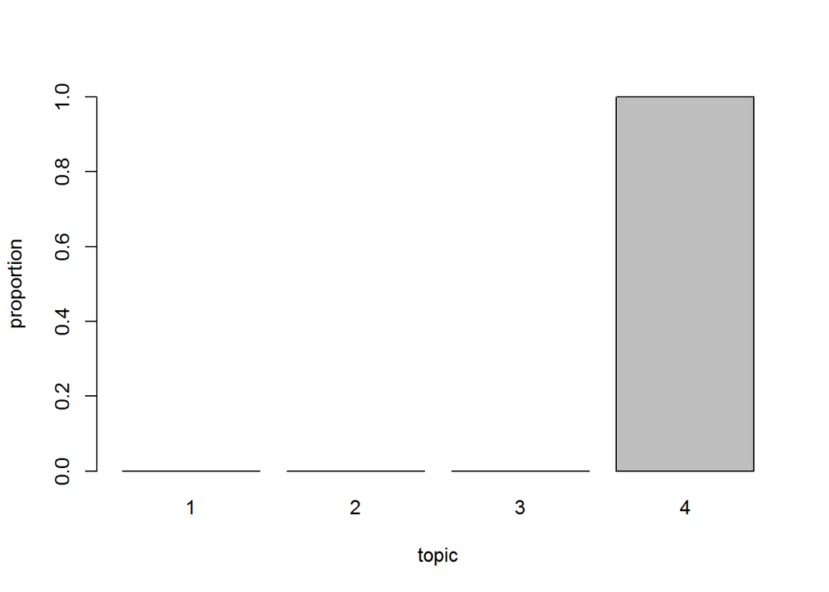

```r
barplot(doc_topic_distr[1, ], xlab = "topic", ylab = "proportion", ylim = c(0, 1), names.arg = 1:ncol(doc_topic_distr))
```

Dans notre cas, le sujet est assez ciblé.

```r
lda_model$get_top_words(n = 10, topic_number = c(1L, 2L, 3L, 4L), lambda = 1)
```

```
##       [,1]             [,2]            [,3]            [,4]
##  [1,] "autoroute"      "stationne"     "stationnement" "gauche"
##  [2,] "route"          "stationnement" "recule"        "lumiere"
##  [3,] "blesse"         "dommages"      "stationne"     "stop"
##  [4,] "fait"           "fait"          "accroche"      "rouge"
##  [5,] "gauche"         "police"        "reculer"       "fait"
##  [6,] "freine"         "accroche"      "stationner"    "blesse"
##  [7,] "vers"           "vers"          "reculant"      "tourne"
##  [8,] "freiner"        "delit_fuite"   "sortir"        "verte"
##  [9,] "perdu_controle" "dommage"       "blesse"        "autre"
## [10,] "roulais"        "porte"         "place"         "intersection"
```

```r
lda_model$get_top_words(n = 10, topic_number = c(1L, 2L, 3L, 4L), lambda = 0.2)
```

```
##       [,1]             [,2]                [,3]            [,4]
##  [1,] "autoroute"      "dommages"          "stationnement" "lumiere"
##  [2,] "perdu_controle" "delit_fuite"       "recule"        "stop"
##  [3,] "route"          "constate"          "reculer"       "rouge"
##  [4,] "hauteur"        "constate_dommages" "reculant"      "gauche"
##  [5,] "pont"           "remarque"          "espace"        "verte"
##  [6,] "courbe"         "matin"             "sortir"        "intersection"
##  [7,] "freiner"        "hier"              "reculais"      "arret"
##  [8,] "aut"            "stationne"         "reculait"      "feu"
##  [9,] "fosset"         "dommage"           "reculons"      "tourne"
## [10,] "freine"         "retour"            "stationner"    "tout_droit"
```

```r
new_dtm <- create_dtm(syntcolloc$transform(it_test), bvtz, type = "dgTMatrix")
new_doc_topic_distr <- lda_model$transform(new_dtm)
```

```
## INFO [2019-05-13 07:41:29] iter 5 loglikelihood = -606496.201
## INFO [2019-05-13 07:41:29] iter 10 loglikelihood = -581580.246
## INFO [2019-05-13 07:41:29] iter 15 loglikelihood = -572808.044
## INFO [2019-05-13 07:41:29] iter 20 loglikelihood = -568442.101
## INFO [2019-05-13 07:41:29] iter 25 loglikelihood = -566262.764
## INFO [2019-05-13 07:41:29] iter 30 loglikelihood = -565084.163
## INFO [2019-05-13 07:41:29] iter 35 loglikelihood = -564479.133
## INFO [2019-05-13 07:41:29] iter 40 loglikelihood = -563758.226
## INFO [2019-05-13 07:41:29] iter 45 loglikelihood = -563683.503
## INFO [2019-05-13 07:41:29] early stopping at 45 iteration
```

```r
perplexity(new_dtm, topic_word_distribution = lda_model$topic_word_distribution, doc_topic_distribution = new_doc_topic_distr)
```

```
## [1] 280.0705
```

Besoin du package LDAvis donc *optionel*

```r
lda_model$plot()
```

## Apprentissage machine

Définir les indices d’entraînement et de validation.

```r
n <- nrow(collisions)
set.seed(8675309)
```

Charger la librairie de boosting de votre choix (xgboost, lightgbm, catboost).

```r
library(xgboost)
```

Préparer les matrices pour l’entraînement en réutilisant notre matrice maison.

```r
mtrx_train <- xgb.DMatrix(modmtrx_train, label = train$target)
mtrx_test <- xgb.DMatrix(modmtrx_test, label = test$target)
```

Entraîner le modèle.

```r
set.seed(8675309)
xgbmodel <- xgb.train(data = mtrx_train,
                      watchlist = list(eval = mtrx_valid, train = mtrx_train),
                      nrounds = 200,
                      objective = "binary:logistic",
                      booster = "gbtree",
                      early_stopping_rounds = 50,
                      print_every_n = 50,
                      max_depth = 15,
                      gamma = 5,
                      subsample = 0.5,
                      colsample_bytree = 1,
                      eta = 0.1)
```

Vérifier les performances.

```r
preds <- predict(xgbmodel, mtrx_test)
obs <- test$target

recall <- function(p) {
  sapply(p, function(p) {
    prd <- as.numeric(preds > p)
    length(which(prd == 1 & obs == 1)) / length(which(obs == 1))
  })
}

precision <- function(p) {
  sapply(p, function(p) {
    prd <- as.numeric(preds > p)
    length(which(prd == 1 & obs == 1)) / length(which(prd == 1))
  })
}

x <- recall((1:250) / 250)
y <- precision((1:250) / 250)

plot(x, y, main = "Validation", xlab = "Recall", ylab = "Precision")
```

[output not shown]